# lab4

## Capraz sinama

Bu bolumde sinama(validasyon) yaklasimi ile cesitli modellerin test veri seti icin hatalari hesaplanarak karsilastirilmalari yapilacaktir.

Modelin validasyonu genel olarak iki turlu yapilir. Birincisi veri setinin bir kismini egitim (modeli kurmak) icin diger kismini sinama icin ayirmaktir. İkincisi derste bahsedilen, capraz gecerliliktir.

Auto verisi incelenecektir. Toplam 392 gozlemin icinden yarisi rasgele olarak sample() komutu ile secilecektir. set.seed() ile herkesin ayni altkumeyi secmesi saglanacaktir.

```r
library(ISLR)
set.seed (1)
data(Auto)
n=dim(Auto)[1]  #veri setindeki gozlem sayisi
train=sample(392,196) #yerine koymadan ornekleme yapilmaktadir
train
```

```
##   [1] 324 167 129 299 270 187 307  85 277 362 330 263 329  79 213  37 105
##  [18] 217 366 165 290 383  89 289 340 326 382  42 111  20  44 343  70 121
##  [35]  40 172  25 248 198  39 298 280 160  14 130  45  22 206 230 193 104
##  [52] 367 255 341 342 103 331  13 296 375 176 279 110  84  29 141 252 221
##  [69] 108 304  33 347 149 287 102 145 118 323 107  64 224 337  51 325 372
##  [86] 138 390 389 282 143 285 170  48 204 295  24 181 214 225 163  43   1
## [103] 328  78 284 116 233  61  86 374  49 242 246 247 239 219 135 364 363
## [120] 310  53 348  65 376 124  77 218  98 194  19  31 174 237  75  16 358
## [137]   9  50  92 122 152 386 207 244 229 350 355 391 223 373 309 140 126
## [154] 349 344 319 258  15 271 388 195 201 318  17 212 127 133  41 384 392
## [171] 159 117  72  36 315 294 157 378 313 306 272 106 185  88 281 228 238
## [188] 368  80  30  93 234 220 240 369 164
```

```r
lm.fit=lm(mpg~horsepower,data=Auto,subset=train)
```

Test veri seti icin hata kareler ortalamasi kucuk olan model tercih edilecektir. Test veri seti hatasinin kucuk olmasi modelin tahmin gucunun iyi oldugu anlamina gelmektedir.

```r
warnings(attach(Auto),F)  #uyarilari kapatmak icin warnings false secildi
#egitim veri seti hata kareler ortalamasi
mean((Auto$mpg-predict(lm.fit,Auto))[train]^2)
```

```
## [1] 25.05959
```

```r
#test veri seti hata kareler ortalamasi
#burada -train yazildiginda egitim veri haricindeki gozlemlerin secilmesi saglanir.
mean((Auto$mpg-predict(lm.fit,Auto))[-train]^2)
```

```
## [1] 23.26601
```

Modellemede amac cesitli modelleri deneyerek test verisi icin hatayi minimize etmektir. Test hatasini minimize eden model optimum model olarak secilecektir.

Auto veri setini hatirlarsak mpg ile horsepower arasinda dogrusal olmayan bir iliski vardi.,

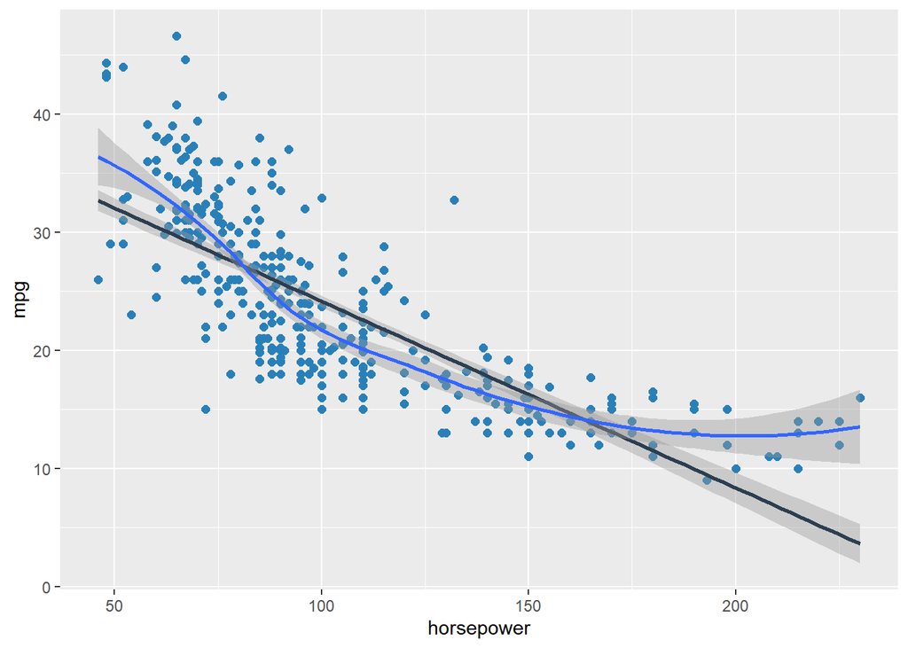

```r
library(ggplot2)
#regresyon dogrusunu guven araligi ile cizmek istersek
ggplot(Auto, aes(x=horsepower, y=mpg)) +
  geom_point(color='#2980B9', size = 2) +
  geom_smooth(method=lm, color='#2C3E50')+
  geom_smooth(method=loess)
```

Bu durumda horsepower degiskeninin karesini veya kupunu modele eklemenin faydali olup olmayacagini arastiralim. poly() fonksiyonu degiskenlerin polinomsal degerlerini modele eklemek icin kullanilabilir.

```r
lm.fit2=lm(mpg~poly(horsepower,2),data=Auto,subset=train) #karesi
warnings(attach(Auto),F)
a=mean((Auto$mpg-predict(lm.fit2,Auto))[-train]^2)
a
```

```
## [1] 18.71646
```

```r
lm.fit3=lm(mpg~poly(horsepower ,3),data=Auto,subset=train)
b=mean((Auto$mpg-predict(lm.fit3,Auto))[-train]^2)
b
```

```
## [1] 18.79401
```

Sirasiyla test seti hatalari `18.7164595` ve `18.7940068` olarak bulunmustur. Egitim ve test ayirimi baska turlu yapilsaydi farkli hata degerleri bulunurdu. seed’i degistirerek tekrar ayni islemleri yapalim.

```r
set.seed (2)
train=sample(392,196)
lm.fit=lm(Auto$mpg~Auto$horsepower ,subset=train)

mean((Auto$mpg-predict(lm.fit,Auto))[-train]^2)
```

```
## [1] 25.72651
```

```r
lm.fit2=lm(Auto$mpg~poly(Auto$horsepower,2),data=Auto,subset=train)

mean((Auto$mpg-predict(lm.fit2,Auto))[-train]^2)
```

```
## [1] 20.43036
```

```r
lm.fit3=lm(Auto$mpg~poly(Auto$horsepower ,3),data=Auto,subset=train)

mean((Auto$mpg-predict(lm.fit3,Auto))[-train]^2)
```

```
## [1] 20.38533
```

Bu sonuclar onceki bulgularimizla tutarlidir. Kuadratik model linear modele gore daha iyi spnuc vermistir ancak kubik modelin daha iyi oldugunu soyleyecek kadar test hatasinda dusme olmamistir.

###Gozlemlerin tek tek cikarilarak validasyon yapilmasi(Leave one out cross validation(LOOCV)) LOOCV her bir gozlemi sirasiyla veri setinden cikarark modelin fit edilip, disarida birakilan gozlem icin test hatasi bulmasi esasina dayanir. Auto veri seti icin 392 tane test hatasi bulunarak bulnlarin ortalamasi alindiginda modelin LOOCV test hatasi bulunmus olur. glm() ve cv.glm() fonksiyonlari bu test hatasini kolaylikla hesaplamaktadir. glm() fonksiyonu da lm() fonksiyonu ile ayni sonuc vermektedir.

```r
glm.fit=glm(mpg~horsepower ,data=Auto)
coef(glm.fit)
```

```
## (Intercept)  horsepower
##  39.9358610  -0.1578447
```

```r
lm.fit=lm(mpg~horsepower ,data=Auto)
coef(lm.fit)
```

```
## (Intercept)  horsepower
##  39.9358610  -0.1578447
```

Bu labda cv.glm() fonksiyonunu kullanmak icin linear regresyon glm() fonksiyonu ile fit edilecektir.

```r
library(boot)
glm.fit=glm(mpg~horsepower ,data=Auto)
cv.err=cv.glm(Auto,glm.fit)
cv.err$delta[1]
```

```
## [1] 24.23151
```

Bu modelde LOOCVA 24.23’tur. Farkli polinom dereceleri icin bu hatayi hesplamak istersek bir dongu olusturmaliyiz.

```r
cv.error=rep(0,5)
for (i in 1:5){
glm.fit=glm(mpg~poly(horsepower ,i),data=Auto)
cv.error[i]=cv.glm(Auto,glm.fit)$delta[1]}
cv.error
```

```
## [1] 24.23151 19.24821 19.33498 19.42443 19.03321
```

###Capraz gecerlilik(k-fold cross validation) Bu yaklasimda veri seti k tane alt kumeye bolunerek her bir k. parca tek tek disarida birakarak model kurulur ve k. parcanin test hatasi hesaplanir. Bu sekilde elimizde k tane test hatasi olmus olur. Bu k tane test hatasinin ortalamasi bize test hatasini verir. Bu yaklasim ikiye ayrimali sinama yaklasiminaa gore daha tercih edilirdir. Bunun sebebi bu yontemde her bir parca veri seti disinda birakilarak daha guvenilir bir tahmin vermesidir. Ayrica LOOCV kadar gucenilirdir ve daha hizli sonuc verdiginden LOOCVye gore de tercih edilir.

```r
set.seed(17)
cv.error.10=rep(0,10)
for (i in 1:10){
glm.fit=glm(mpg~poly(horsepower ,i),data=Auto)
cv.error.10[i]=cv.glm(Auto,glm.fit,K=10)$delta[1]}
cv.error.10
```

```
##  [1] 24.27207 19.26909 19.34805 19.29496 19.03198 18.89781 19.12061
##  [8] 19.14666 18.87013 20.95520
```

##Odev 4

Asagidaki gibi bir veri seti uretiniz.

```r
set.seed(1)
x=rnorm(100)
y=x-2*x^2+rnorm(100)
```

- 1-X ve y’nin sacilim grafigini olusturunuz yorumlayiniz.

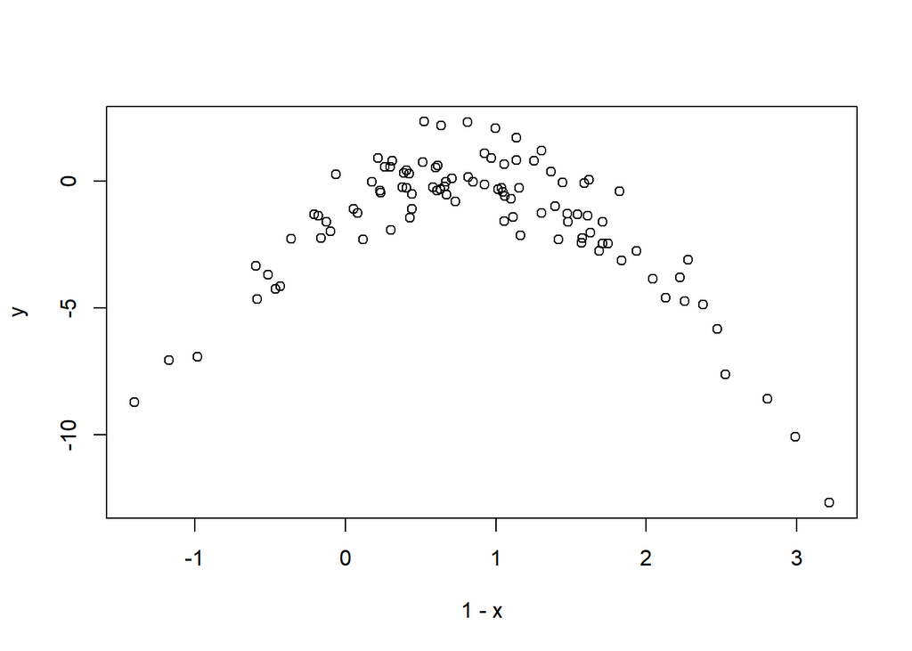

```r
plot(1-x,y)
```

burada ters huni seklinde bir grafik elde ettik. lineer olmasi icin bazi iyilestirmeler yapmaliyiz.

- 2-4. dereceye kadar polinom modelleri olusturunuz(4 tane model olusturulacak). Rasgele bir seed secerek Her biri icin LOOCV modelleri olusturunuz.

```r
library(ISLR)
set.seed (1)
train=sample(100,70) #yerine koymadan ornekleme yapilmaktadir
train
```

```
##  [1]  68  39   1  34  87  43  14  82  59  51  85  21  54  74   7  73  79
## [18]  37  83  97  44  84  33  35  70  96  42  38  20  28  72  80  40  69
## [35]  25  99  91  75   6  24  32  94   2  45  18  22  92  90  98  64 100
## [52]  62  23  67  49  50  65  11  17  36  13  66  47  48  76  29  57  55
## [69]  77  71
```

```r
lm.fit2=lm(y~poly(1-x,2),subset=train) #karesi

a=mean((y-predict(lm.fit2))[-train]^2)
a
```

```
## [1] 6.506859
```

```r
lm.fit3=lm(y~poly(1-x ,3),subset=train)
b=mean((y-predict(lm.fit3))[-train]^2)
b
```

```
## [1] 6.481869
```

```r
set.seed (2)
train=sample(100,70)

lm.fit=lm(y~x ,subset=train)
mean((y-predict(lm.fit))[-train]^2)
```

```
## [1] 12.7498
```

```r
lm.fit2=lm(y~poly(x,2),subset=train)
mean((y-predict(lm.fit2))[-train]^2)
```

```
## [1] 15.54182
```

```r
lm.fit3=lm(y~poly(x,3),subset=train)
mean((y-predict(lm.fit3))[-train]^2)
```

```
## [1] 15.62835
```

```r
lm.fit4=lm(y~poly(x,4),subset=train)
mean((y-predict(lm.fit4))[-train]^2)
```

```
## [1] 15.76126
```

- 3-Baska bir seed secerek 2. maddeyi tekrarlayiniz. Sonuclar ayni midir?

```r
set.seed (8)
train=sample(100,70)

lm.fit=lm(y~x ,subset=train)
mean((y-predict(lm.fit))[-train]^2)
```

```
## [1] 11.46878
```

```r
lm.fit2=lm(y~poly(x,2),subset=train)
mean((y-predict(lm.fit2))[-train]^2)
```

```
## [1] 12.88538
```

```r
lm.fit3=lm(y~poly(x,3),subset=train)
mean((y-predict(lm.fit3))[-train]^2)
```

```
## [1] 12.94061
```

```r
lm.fit4=lm(y~poly(x,4),subset=train)
mean((y-predict(lm.fit4))[-train]^2)
```

```
## [1] 13.01589
```

sonuclar farklidir. 2. , 3. ve 4. kuvvetler birbirine yakin degerler veriyor.

- 4-Hangi model en kucuk LOOCV yi verdi? Sonuc beklediginiz gibi mi aciklayiniz.

- 5-Her bir modelin katsayilarinin anlamliligina bakiniz. Capraz sinama sonuclari ile katsayi anlamliliklari birbirine uyumlu mudur?